# Supplement: Symmetric Case

2023-03-28

We test whether we can use the independence of ranks of the same column element in two different rows.

First, we set up the parameters: number of runs, the size of the matrix, and whether the main diagonal is zero.

```r
n<-1000
set.seed(42)
```

```r
msize<-100
```

# Symmetric square 100x100 matrix

We make a symmetric random matrix n times and then we save the ranks of 3 row in 1 column and in second column for each permutation.

```r
zerodiag<-FALSE
two_columns<-data.table('u31'=rep(-1,n),'u32'=rep(-1,n))
for (i in 1:n) {
  matr<-matrix(runif(msize**2),nrow=msize)
  matr<-matr+t(matr)
  if(zerodiag) {diag(matr)<-0}
  else {diag(matr)<-runif(msize)+runif(msize)}
  #we regenerate diag to be from the same distrib
  #everything is now sum of two runif,
  #and  the diag before we regenetate it is is from 2*runif
  two_columns[i,1]<-msize-rank(matr[,1])[3]
  two_columns[i,2]<-msize-rank(matr[,2])[3]
}
```

The Kendall correlation does not detect any correlation between the vectors.

```r
cor.test(two_columns[[1]],two_columns[[2]],method="kendall")
```

```
##
##  Kendall's rank correlation tau
##
## data:  two_columns[[1]] and two_columns[[2]]
## z = 1.5274, p-value = 0.1267
## alternative hypothesis: true tau is not equal to 0
## sample estimates:
##        tau
## 0.03257849
```

Let’s plot the results.

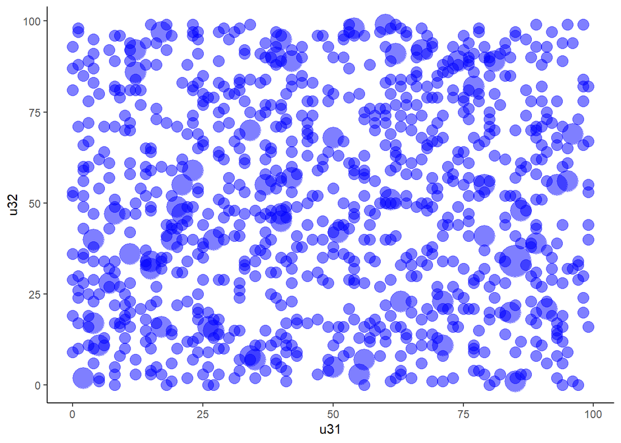

```r
two_columns<-two_columns %>% count (u31,u32,name="counter")
scale<-median(two_columns$counter)/4
dots <- ggplot(two_columns,aes(x=u31,y=u32)) +
  geom_point(size=two_columns$counter/scale,alpha=0.5,col="blue") +
  theme_classic()
plot(dots)
```

Let’s test the uniformity.

```r
chisq.test(two_columns$counter)
```

```
##
##  Chi-squared test for given probabilities
##
## data:  two_columns$counter
## X-squared = 53.92, df = 940, p-value = 1
```

```r
msize<-50
```

# Symmetric square 50x50 matrix

We make a symmetric random matrix n times and then we save the ranks of 3 row in 1 column and in second column for each permutation.

```r
zerodiag<-FALSE
two_columns<-data.table('u31'=rep(-1,n),'u32'=rep(-1,n))
for (i in 1:n) {
  matr<-matrix(runif(msize**2),nrow=msize)
  matr<-matr+t(matr)
  if(zerodiag) {diag(matr)<-0}
  else {diag(matr)<-runif(msize)+runif(msize)}
  #we regenerate diag to be from the same distrib
  #everything is now sum of two runif,
  #and  the diag before we regenetate it is is from 2*runif
  two_columns[i,1]<-msize-rank(matr[,1])[3]
  two_columns[i,2]<-msize-rank(matr[,2])[3]
}
```

The Kendall correlation does not detect any correlation between the vectors.

```r
cor.test(two_columns[[1]],two_columns[[2]],method="kendall")
```

```
##
##  Kendall's rank correlation tau
##
## data:  two_columns[[1]] and two_columns[[2]]
## z = -0.44691, p-value = 0.6549
## alternative hypothesis: true tau is not equal to 0
## sample estimates:
##          tau
## -0.009629366
```

Let’s plot the results.

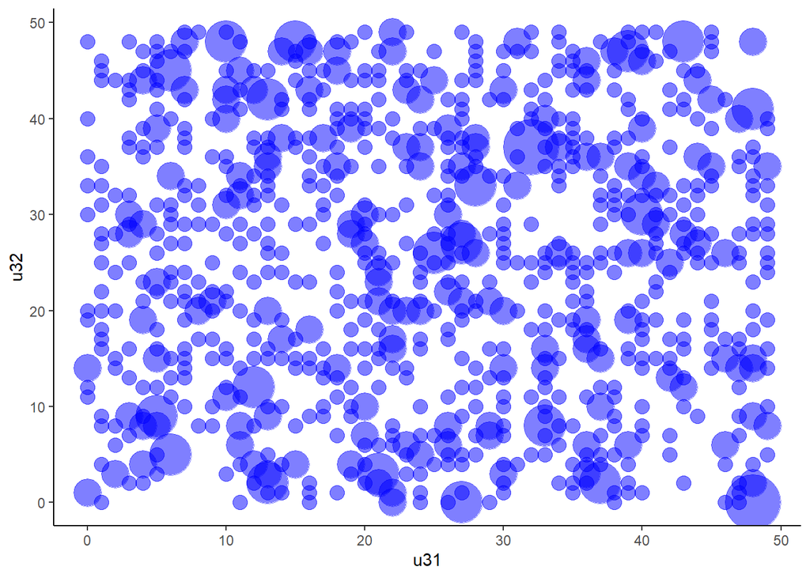

```r
two_columns<-two_columns %>% count (u31,u32,name="counter")
scale<-median(two_columns$counter)/4
dots <- ggplot(two_columns,aes(x=u31,y=u32)) +
  geom_point(size=two_columns$counter/scale,alpha=0.5,col="blue") +
  theme_classic()
plot(dots)
```

Let’s test the uniformity.

```r
chisq.test(two_columns$counter)
```

```
##
##  Chi-squared test for given probabilities
##
## data:  two_columns$counter
## X-squared = 158.3, df = 809, p-value = 1
```

```r
msize<-10
```

# Symmetric square 10x10 matrix

We make a symmetric random matrix n times and then we save the ranks of 3 row in 1 column and in second column for each permutation.

```r
zerodiag<-FALSE
two_columns<-data.table('u31'=rep(-1,n),'u32'=rep(-1,n))
for (i in 1:n) {
  matr<-matrix(runif(msize**2),nrow=msize)
  matr<-matr+t(matr)
  if(zerodiag) {diag(matr)<-0}
  else {diag(matr)<-runif(msize)+runif(msize)}
  #we regenerate diag to be from the same distrib
  #everything is now sum of two runif,
  #and  the diag before we regenetate it is is from 2*runif
  two_columns[i,1]<-msize-rank(matr[,1])[3]
  two_columns[i,2]<-msize-rank(matr[,2])[3]
}
```

The Kendall correlation does not detect any correlation between the vectors.

```r
cor.test(two_columns[[1]],two_columns[[2]],method="kendall")
```

```
##
##  Kendall's rank correlation tau
##
## data:  two_columns[[1]] and two_columns[[2]]
## z = 1.2227, p-value = 0.2214
## alternative hypothesis: true tau is not equal to 0
## sample estimates:
##        tau
## 0.02840357
```

Let’s plot the results.

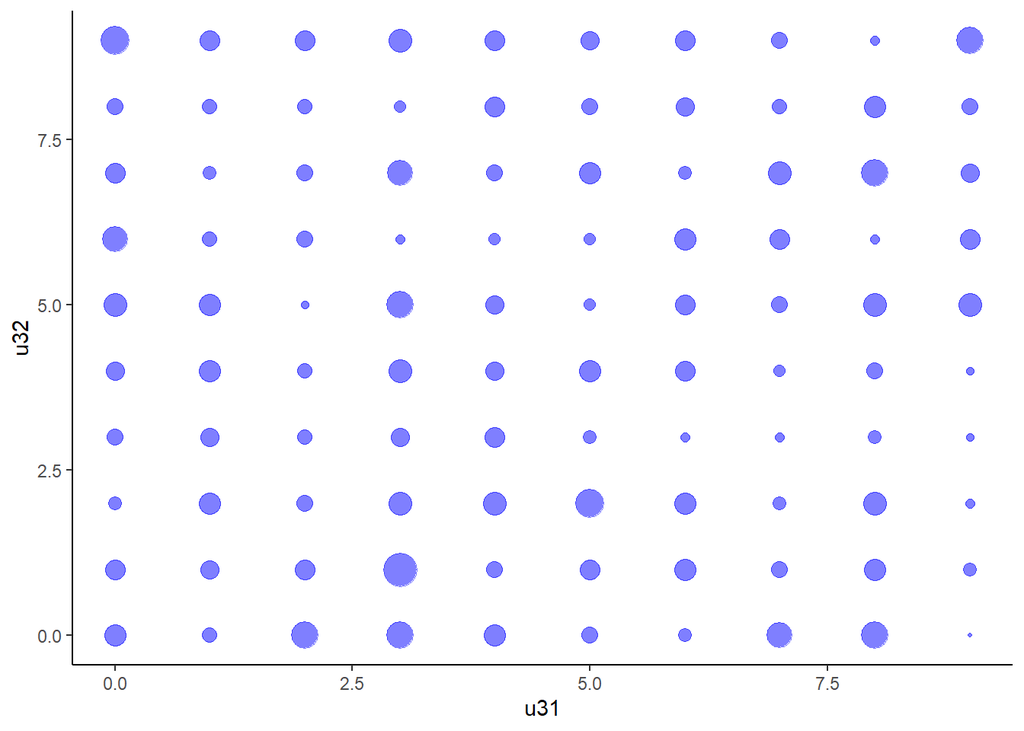

```r
two_columns<-two_columns %>% count (u31,u32,name="counter")
scale<-median(two_columns$counter)/4
dots <- ggplot(two_columns,aes(x=u31,y=u32)) +
  geom_point(size=two_columns$counter/scale,alpha=0.5,col="blue") +
  theme_classic()
plot(dots)
```

Let’s test the uniformity.

```r
chisq.test(two_columns$counter)
```

```
##
##  Chi-squared test for given probabilities
##
## data:  two_columns$counter
## X-squared = 101, df = 99, p-value = 0.4252
```

```r
msize<-100
```

# Symmetric square 100x100 matrix, zero diagonal

```r
zerodiag<-TRUE
two_columns<-data.table('u31'=rep(-1,n),'u32'=rep(-1,n))
for (i in 1:n) {
  matr<-matrix(runif(msize**2),nrow=msize)
  matr<-matr+t(matr)
  if(zerodiag) {diag(matr)<-0}
  else {diag(matr)<-runif(msize)+runif(msize)}
  #we regenerate diag to be from the same distrib
  #everything is now sum of two runif,
  #and  the diag before we regenetate it is is from 2*runif
  two_columns[i,1]<-msize-rank(matr[,1])[3]
  two_columns[i,2]<-msize-rank(matr[,2])[3]
}
```

```r
cor.test(two_columns[[1]],two_columns[[2]],method="kendall")
```

```
##
##  Kendall's rank correlation tau
##
## data:  two_columns[[1]] and two_columns[[2]]
## z = 0.48543, p-value = 0.6274
## alternative hypothesis: true tau is not equal to 0
## sample estimates:
##        tau
## 0.01035421
```

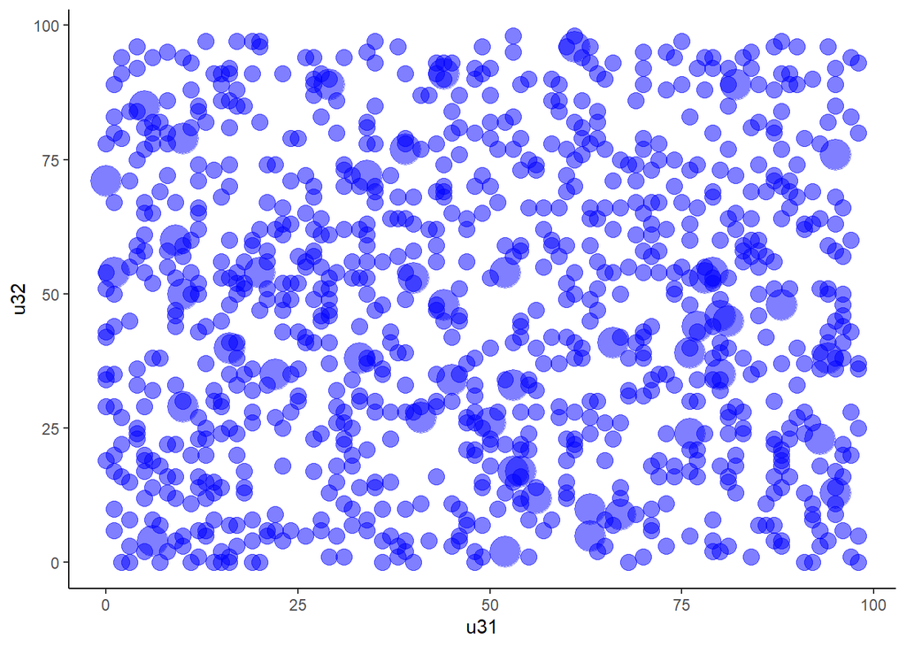

```r
two_columns<-two_columns %>% count (u31,u32,name="counter")
scale<-median(two_columns$counter)/4
dots <- ggplot(two_columns,aes(x=u31,y=u32)) +
  geom_point(size=two_columns$counter/scale,alpha=0.5,col="blue") +
  theme_classic()
plot(dots)
```

```r
chisq.test(two_columns$counter)
```

```
##
##  Chi-squared test for given probabilities
##
## data:  two_columns$counter
## X-squared = 41.768, df = 953, p-value = 1
```

# Asymmetric square 100x100 matrix

Let’s run the procedure for a random asymmetric square matrix.

```r
zerodiag<-FALSE
two_columns<-data.table('u31'=rep(-1,n),'u32'=rep(-1,n))
for (i in 1:n) {
  matr<-matrix(runif(msize**2),nrow=msize)
  #matr<-matr+t(matr)
  #symmetriser, commented
  if(zerodiag) {diag(matr)<-0}
  two_columns[i,1]<-msize-rank(matr[,1])[3]
  two_columns[i,2]<-msize-rank(matr[,2])[3]
}
```

The Kendall correlation does not detect any correlation between the vectors.

```r
cor.test(two_columns[[1]],two_columns[[2]],method="kendall")
```

```
##
##  Kendall's rank correlation tau
##
## data:  two_columns[[1]] and two_columns[[2]]
## z = 0.25665, p-value = 0.7974
## alternative hypothesis: true tau is not equal to 0
## sample estimates:
##        tau
## 0.00547415
```

Let’s plot the results.

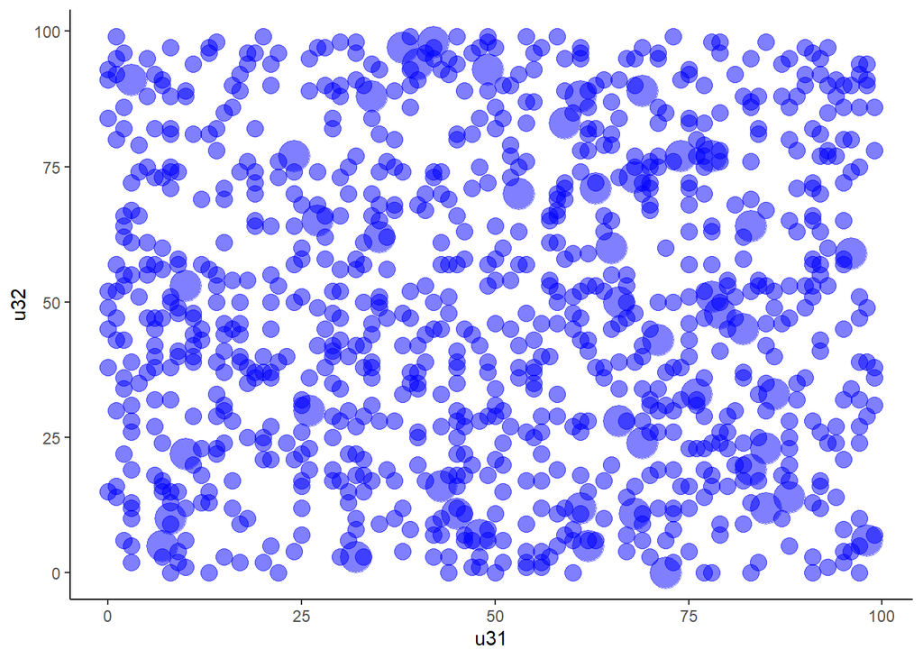

```r
two_columns<-two_columns %>% count (u31,u32,name="counter")
scale<-median(two_columns$counter)/4
dots <- ggplot(two_columns,aes(x=u31,y=u32)) +
  geom_point(size=two_columns$counter/scale,alpha=0.5,col="blue") +
  theme_classic()
plot(dots)
```

Let’s test the uniformity.

```r
chisq.test(two_columns$counter)
```

```
##
##  Chi-squared test for given probabilities
##
## data:  two_columns$counter
## X-squared = 42.582, df = 952, p-value = 1
```

# Asymmetric square 100x100 matrix, zero diagonal

Let’s run the procedure for a random asymmetric square matrix.

```r
zerodiag<-TRUE
two_columns<-data.table('u31'=rep(-1,n),'u32'=rep(-1,n))
for (i in 1:n) {
  matr<-matrix(runif(msize**2),nrow=msize)
  #matr<-matr+t(matr)
  #symmetriser, commented
  if(zerodiag) {diag(matr)<-0}
  two_columns[i,1]<-msize-rank(matr[,1])[3]
  two_columns[i,2]<-msize-rank(matr[,2])[3]
}
```

The Kendall correlation does not detect any correlation between the vectors.

```r
cor.test(two_columns[[1]],two_columns[[2]],method="kendall")
```

```
##
##  Kendall's rank correlation tau
##
## data:  two_columns[[1]] and two_columns[[2]]
## z = 1.5614, p-value = 0.1184
## alternative hypothesis: true tau is not equal to 0
## sample estimates:
##        tau
## 0.03330536
```

Let’s plot the results.

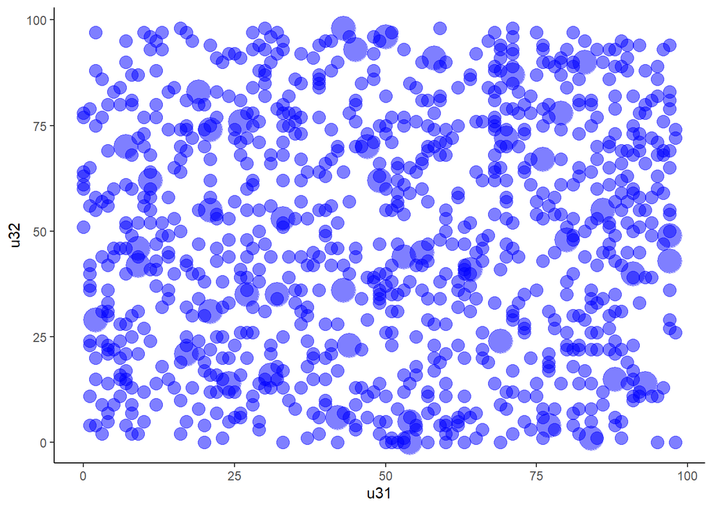

```r
two_columns<-two_columns %>% count (u31,u32,name="counter")
scale<-median(two_columns$counter)/4
dots <- ggplot(two_columns,aes(x=u31,y=u32)) +
  geom_point(size=two_columns$counter/scale,alpha=0.5,col="blue") +
  theme_classic()
plot(dots)
```

Let’s test the uniformity.

```r
chisq.test(two_columns$counter)
```

```
##
##  Chi-squared test for given probabilities
##
## data:  two_columns$counter
## X-squared = 40.95, df = 954, p-value = 1
```

# Nonsquare 100x200matrix

For control, let’s run the procedure for a nonsquare matrix.

```r
two_columns<-data.table('u31'=rep(-1,n),'u32'=rep(-1,n))
nsize=2*msize
for (i in 1:n) {
  matr<-matrix(runif(msize*nsize),nrow=msize)
  two_columns[i,1]<-msize-rank(matr[,1])[3]
  two_columns[i,2]<-msize-rank(matr[,2])[3]
}
```

The Kendall correlation does not detect any correlation between the vectors.

```r
cor.test(two_columns[[1]],two_columns[[2]],method="kendall")
```

```
##
##  Kendall's rank correlation tau
##
## data:  two_columns[[1]] and two_columns[[2]]
## z = -1.3207, p-value = 0.1866
## alternative hypothesis: true tau is not equal to 0
## sample estimates:
##         tau
## -0.02817138
```

Let’s plot the results.

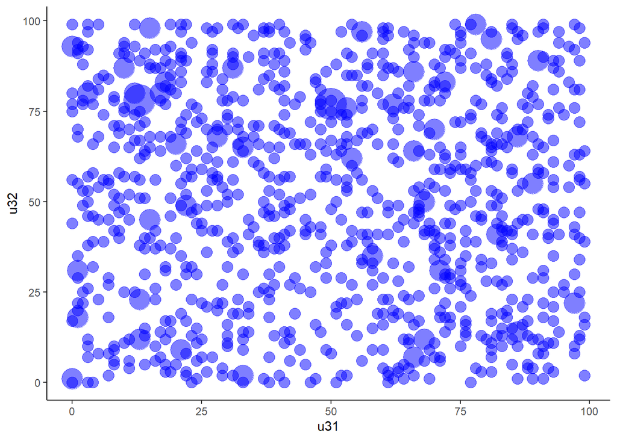

```r
two_columns<-two_columns %>% count (u31,u32,name="counter")
scale<-median(two_columns$counter)/4
dots <- ggplot(two_columns,aes(x=u31,y=u32)) +
  geom_point(size=two_columns$counter/scale,alpha=0.5,col="blue") +
  theme_classic()
plot(dots)
```

Let’s test the uniformity.

```r
chisq.test(two_columns$counter)
```

```
##
##  Chi-squared test for given probabilities
##
## data:  two_columns$counter
## X-squared = 44.77, df = 954, p-value = 1
```